# Laboratorium Nr.1 LUKASZ ZAJAC

# PREDATOR-PREY MODELS

1. Zarejestrować się (jeżeli ktoś jeszcze tego nie zrobił) na ChatGPT (może być też inny chat AI np. Copilot lub Gemini).

DONE.

2. Zadać odpowiednie pytanie by zorientować się jakie najbardziej znane modele drapieżnik-ofiara (np. 10 najbardziej znanych) w różnych dziedzinach są rozpoznawane w literaturze naukowej. Pytania do chata proszę zadawać w języku angielskim.

Here is a list of 10 well-known and important predator-prey models across different domains:

Lotka-Volterra Model (Biology & Ecology)

Holling Type Functional Response (Ecology)

Rosenzweig-MacArthur Model (Ecology)

Nicholson-Bailey Model (Insect Population Dynamics)

Predator-Prey Model with Allee Effect (Ecology)

Economic Predator-Prey Model (Economics)

Epidemiological SIR Model (Disease Spread)

Internet Traffic Models (Computer Networks)

Data-Cache Predator-Prey Models (Computer Science)

Human Predation on Natural Resources (Environmental Science)

3. Wybrać sobie jeden z modeli.

Economic Predator-Prey Model (Economics)

4. Następnie uszczegółowić ten model tak by posiadał przynajmniej 3 zmienne dynamiczne (D>=3). Zadać pytanie by chatGPT skonstruował pełny model formalny. Na tym etapie uszczegółowić model, dodać jakieś nowe elementy. W raporcie krótko napisać dlaczego ten model wygląda tak a nie inaczej.

### Extending the Predator-Prey Model in Economics

To create a more detailed **predator-prey** model in economics with at least three dynamic variables ((D \geq 3)), we can incorporate the following elements:

1. **Market Capital (K)**: A dynamic variable representing the financial and capital resources of firms. The capital of large firms (predators) increases as they take over smaller firms, while the capital of small firms (prey) decreases due to competition.
2. **Market Share (M)**: A variable describing the firms' share of the market. Large firms (predators) increase their market share at the expense of smaller firms, while the market share of small firms decreases.
3. **Investment Strategy (I)**: A variable representing the firms' investment strategies, affecting how quickly they can grow their capital and market share. Large firms may speed up their investments to outcompete, while small firms may need to scale back their investments.

### Formalization of the Model

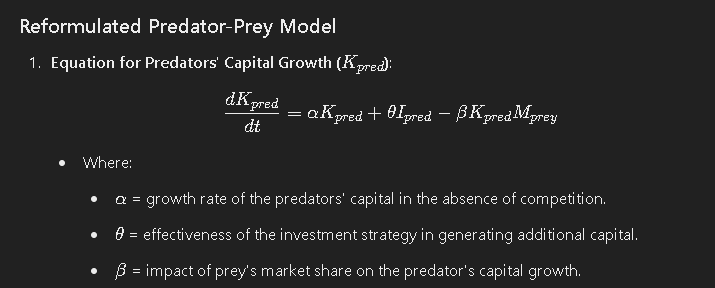

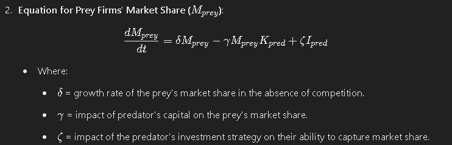

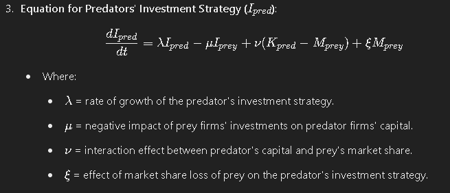

### Explanation of the Model

Predators' Capital Growth (𝐾):

This equation shows that predators' capital grows based on its current amount, the effectiveness of their investment strategies, and is negatively impacted by competition from prey firms' market share.

Prey Firms' Market Share (𝑀):

This equation indicates that the market share of prey firms can grow independently but is negatively affected by competition with predators. However, it can also benefit from any strategic investments made by the predators.

### Conclusion

These reformulated equations create a more cohesive model where the investment strategy is a dynamic variable that interacts meaningfully with both capital growth and market share. This enhances the model's realism, better reflecting the competitive dynamics between large and small firms in an economic context.

### Zmiany

czat zrobil model z K M i I, ale K i M byly niezalezne od I. Po zwroceniu na to uwage uzupelnil wzory i aktualnie mysle ze ma to sens.

5. Przyglądnąć się równaniom modelu (czy rozumieją Państwo jak zostały skonstruowane). Zaproponować w nim rozsądne poprawki.

Generalnie rozumiem, natomiast czy model bedzie faktycznie jakos dzialal mam nadzieje sie przekonac w kolejnych punktach.

6. Zaimplementować model (chat zrobi to sam, ale nie w sposób optymalny, dlatego należy kod zweryfikować).

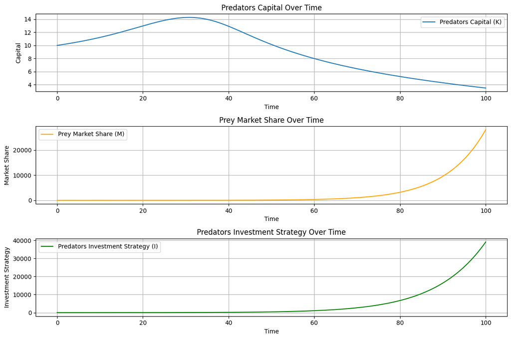

```python
import numpy as np
import matplotlib.pyplot as plt
from scipy.integrate import odeint

# Parameters
alpha = 0.1    # Growth rate of predator's capital
beta = 0.02    # Impact of prey's market share on predator's capital
theta = 0.05   # Effectiveness of investment strategy on capital growth

delta = 0.1    # Growth rate of prey's market share
gamma = 0.01   # Impact of predator's capital on prey's market share
zeta = 0.03    # Impact of predator's investment strategy on market share

lambda_invest = 0.1  # Growth rate of predator's investment strategy
mu = 0.01           # Negative impact of prey's investment on predator's capital
nu = 0.02           # Interaction effect between predator's capital and prey's market share
xi = 0.01           # Effect of market share loss on predator's investment

# Define the system of equations
def model(y, t):
    K_pred, M_prey, I_pred = y
    dK_pred_dt = alpha * K_pred + theta * I_pred - beta * K_pred * M_prey
    dM_prey_dt = delta * M_prey - gamma * M_prey * K_pred + zeta * I_pred
    dI_pred_dt = lambda_invest * I_pred - mu * M_prey + nu * (K_pred - M_prey) + xi * M_prey
    return [dK_pred_dt, dM_prey_dt, dI_pred_dt]

# Initial conditions
K_pred0 = 10  # Initial capital of predators
M_prey0 = 5   # Initial market share of prey
I_pred0 = 2   # Initial investment strategy of predators
y0 = [K_pred0, M_prey0, I_pred0]

# Time points to evaluate the solution
t = np.linspace(0, 100, 3000)  # From t=0 to t=100

# Solve the ODE
solution = odeint(model, y0, t)

# Plotting the results
K_pred, M_prey, I_pred = solution.T

plt.figure(figsize=(12, 8))

plt.subplot(3, 1, 1)
plt.plot(t, K_pred, label='Predators Capital (K)')
plt.title('Predators Capital Over Time')
plt.xlabel('Time')
plt.ylabel('Capital')
plt.grid()
plt.legend()

plt.subplot(3, 1, 2)
plt.plot(t, M_prey, label='Prey Market Share (M)', color='orange')
plt.title('Prey Market Share Over Time')
plt.xlabel('Time')
plt.ylabel('Market Share')
plt.grid()
plt.legend()

plt.subplot(3, 1, 3)
plt.plot(t, I_pred, label='Predators Investment Strategy (I)', color='green')
plt.title('Predators Investment Strategy Over Time')
plt.xlabel('Time')
plt.ylabel('Investment Strategy')
plt.grid()
plt.legend()

plt.tight_layout()
plt.show()
```

7. Poprosić by dobrał sam parametry modelu i narysował przykładowe przebiegi czasowe zmiennych dynamicznych także w przestrzeni fazowej (dla D=3: (x,y,z)). Czasem ze względu na obciążenie nie wykona polecenia rysowania, dlatego przejść do punktu 9 lub użyć np. Copilot’a.

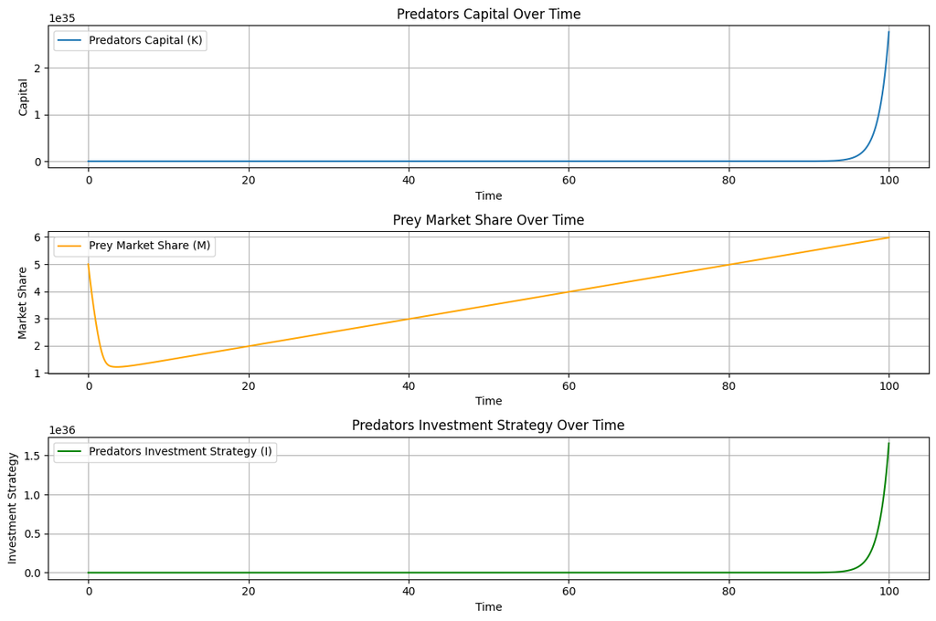

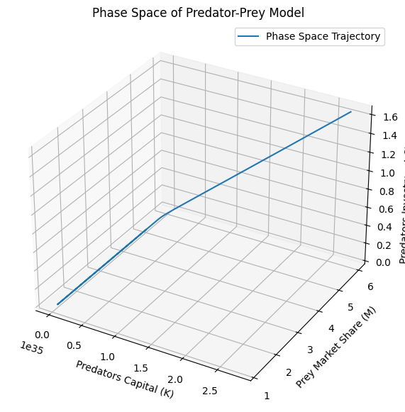

```python
import numpy as np
import matplotlib.pyplot as plt
from scipy.integrate import odeint
from mpl_toolkits.mplot3d import Axes3D

# Randomly chosen parameters for the model
alpha = 0.8      # Increased growth rate of predator's capital
beta = 0.15      # Increased impact of prey's market share on predator's capital
theta = 0.15     # Increased effectiveness of investment strategy on capital growth

delta = 0.8     # Increased growth rate of prey's market share
gamma = 0.15     # Increased impact of predator's capital on prey's market share
zeta = 0.15      # Increased impact of predator's investment strategy on market share

lambda_invest = 0.8  # Increased growth rate of predator's investment strategy
mu = 0.05            # Increased negative impact of prey's investment on predator's capital
nu = 0.05            # Increased interaction effect between predator's capital and prey's market share
xi = 0.02            # Effect of market share loss on predator's investment

# Define the system of equations
def model(y, t):
    K_pred, M_prey, I_pred = y
    dK_pred_dt = alpha * K_pred + theta * I_pred - beta * K_pred * M_prey
    dM_prey_dt = delta * M_prey - gamma * M_prey * K_pred + zeta * I_pred
    dI_pred_dt = lambda_invest * I_pred - mu * M_prey + nu * (K_pred - M_prey) + xi * M_prey
    return [dK_pred_dt, dM_prey_dt, dI_pred_dt]

# Initial conditions
K_pred0 = 10  # Initial capital of predators
M_prey0 = 5   # Initial market share of prey
I_pred0 = 5   # Initial investment strategy of predators
y0 = [K_pred0, M_prey0, I_pred0]
# Time points to evaluate the solution
t = np.linspace(0, 100, 5000)  # From t=0 to t=100

# Solve the ODE
solution = odeint(model, y0, t)

# Extract results
K_pred, M_prey, I_pred = solution.T

# Plotting the results
plt.figure(figsize=(12, 8))

# Time series plots
plt.subplot(3, 1, 1)
plt.plot(t, K_pred, label='Predators Capital (K)')
plt.title('Predators Capital Over Time')
plt.xlabel('Time')
plt.ylabel('Capital')
plt.grid()
plt.legend()

plt.subplot(3, 1, 2)
plt.plot(t, M_prey, label='Prey Market Share (M)', color='orange')
plt.title('Prey Market Share Over Time')
plt.xlabel('Time')
plt.ylabel('Market Share')
plt.grid()
plt.legend()

plt.subplot(3, 1, 3)
plt.plot(t, I_pred, label='Predators Investment Strategy (I)', color='green')
plt.title('Predators Investment Strategy Over Time')
plt.xlabel('Time')
plt.ylabel('Investment Strategy')
plt.grid()
plt.legend()

plt.tight_layout()
plt.show()

# Phase space plot
fig = plt.figure(figsize=(10, 7))
ax = fig.add_subplot(111, projection='3d')
ax.plot(K_pred, M_prey, I_pred, label='Phase Space Trajectory')
ax.set_xlabel('Predators Capital (K)')
ax.set_ylabel('Prey Market Share (M)')
ax.set_zlabel('Predators Investment Strategy (I)')
ax.set_title('Phase Space of Predator-Prey Model')
ax.legend()
plt.show()
```

8. Skorygować te zmienne (wersja 3.5 nie pozwoli na generacje dużej liczby wykresów, dlatego kod przenieść do lokalnie zainstalowanego Pythona).
9. Próbować tak dobrać zmienne by układ stał się chaotyczny.

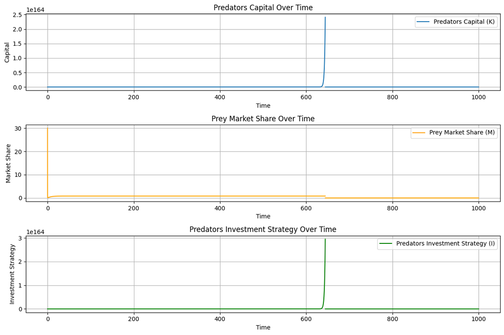

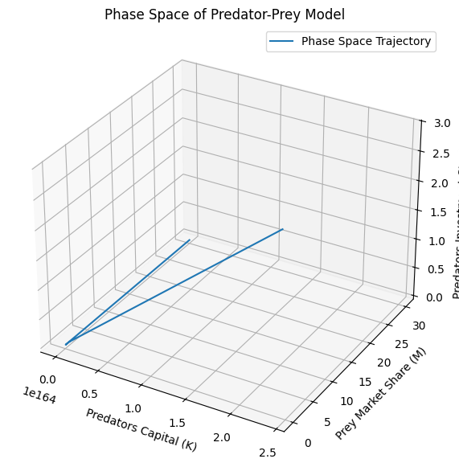

```python
import numpy as np
import matplotlib.pyplot as plt
from scipy.integrate import odeint
from mpl_toolkits.mplot3d import Axes3D

# Adjusted parameters for chaotic behavior
alpha = 0.5      # Growth rate of predator's capital
beta = 0.2       # Impact of prey's market share on predator's capital
theta = 0.2      # Effectiveness of investment strategy on capital growth

delta = 0.5      # Growth rate of prey's market share
gamma = 0.3      # Impact of predator's capital on prey's market share
zeta = 0.2       # Impact of predator's investment strategy on market share

lambda_invest = 0.5  # Growth rate of predator's investment strategy
mu = 0.1             # Negative impact of prey's investment on predator's capital
nu = 0.1             # Interaction effect between predator's capital and prey's market share
xi = 0.1             # Effect of market share loss on predator's investment

# Define the system of equations
def model(y, t):
    K_pred, M_prey, I_pred = y
    dK_pred_dt = alpha * K_pred + theta * I_pred - beta * K_pred * M_prey
    dM_prey_dt = delta * M_prey - gamma * M_prey * K_pred + zeta * I_pred
    dI_pred_dt = lambda_invest * I_pred - mu * M_prey + nu * (K_pred - M_prey) + xi * M_prey
    return [dK_pred_dt, dM_prey_dt, dI_pred_dt]

# Initial conditions
K_pred0 = 100  # Initial capital of predators
M_prey0 = 30   # Initial market share of prey
I_pred0 = 10   # Initial investment strategy of predators
y0 = [K_pred0, M_prey0, I_pred0]

# Time points to evaluate the solution
t = np.linspace(0, 1000, 50000)  # From t=0 to t=1000

# Solve the ODE
solution = odeint(model, y0, t)

# Extract results
K_pred, M_prey, I_pred = solution.T

# Plotting the results
plt.figure(figsize=(12, 8))

# Time series plots
plt.subplot(3, 1, 1)
plt.plot(t, K_pred, label='Predators Capital (K)')
plt.title('Predators Capital Over Time')
plt.xlabel('Time')
plt.ylabel('Capital')
plt.grid()
plt.legend()

plt.subplot(3, 1, 2)
plt.plot(t, M_prey, label='Prey Market Share (M)', color='orange')
plt.title('Prey Market Share Over Time')
plt.xlabel('Time')
plt.ylabel('Market Share')
plt.grid()
plt.legend()

plt.subplot(3, 1, 3)
plt.plot(t, I_pred, label='Predators Investment Strategy (I)', color='green')
plt.title('Predators Investment Strategy Over Time')
plt.xlabel('Time')
plt.ylabel('Investment Strategy')
plt.grid()
plt.legend()

plt.tight_layout()
plt.show()

# Phase space plot
fig = plt.figure(figsize=(10, 7))
ax = fig.add_subplot(111, projection='3d')
ax.plot(K_pred, M_prey, I_pred, label='Phase Space Trajectory')
ax.set_xlabel('Predators Capital (K)')
ax.set_ylabel('Prey Market Share (M)')
ax.set_zlabel('Predators Investment Strategy (I)')
ax.set_title('Phase Space of Predator-Prey Model')
ax.legend()
plt.show()
```

10. W raporcie opisać końcowy model i porównać go do pierwotnie wygenerowanego przez chat. Przeanalizować i przedyskutować ciekawe wyniki otrzymane przy pomocy modelu.

Model zaproponowany przez czat wydaje sie sensowny, natomiast po kilkudziesieciu probach nie jestem w stanie osiagnac zadnego cyklicznego zachowania. Male zmiany w parametrach zmieniaja calkowicie jego zachowanie i ciezkie jest to do przeanalizowania na takim prostym pyplocie. Zalamuje rece i nie wiem jak to dalej pociagnac niz slepo strzelac malymi zmianami. W powyzszym wyniku doszedlem juz do jakiejsc nieciaglosci nawet. Dodatkowo mam wrazenie ze pojawiaja sie bledy numeryczne, bo jak wykres spada gwaltownie w do 0 nagle wybija sie wysoko w kolejnym kroku

11. Do raportu dołączyć najważniejsze pytania zadane chat’owi. Na ocenę będzie miał największy wpływ odpowiedni wybór modelu formalnego.

(dla wytrwałych) Spróbować określić do jakiej złożoności zadanego modelu chat daje sobie radę z jego konstrukcją.

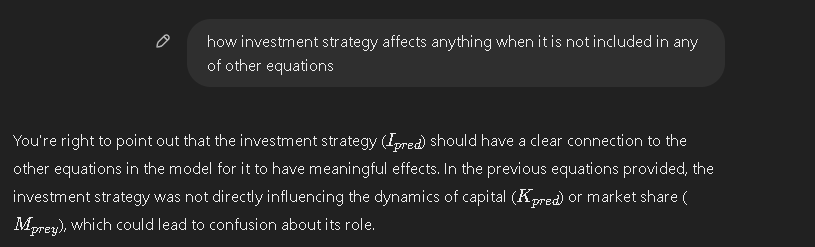